# GAL - BarvenĂ grafu

Martin KosĂk

prosince 2015

## ZadĂˇnĂ

Na rĹŻznÄ› hustĂ˝ch grafech prozkoumĂˇme rozdĂly v jednotlivĂ˝ch pĹ™edstavenĂ˝ch algoritmech barvenĂ grafu, konkrĂ©tnÄ› nĂˇm pĹŻjde o algoritmy LF, Welsh-PowellĹŻv, RLF a DSATUR. N-krĂˇt (hodnota N bude upĹ™esnÄ›na nĂĹľe) provĂˇdÄ›jte nĂˇsledujĂcĂ cyklus.

Zvolte poÄŤet vrcholĹŻ. PoÄŤet vrcholĹŻ volte nĂˇhodnÄ› mezi 90 a 110 (jinĂ˝mi slovy 100 vrcholĹŻ plus mĂnus 10 %). Pro zvolenĂ˝ poÄŤet vrcholĹŻ sestavte vĹľdy ÄŤtyĹ™i grafy, pro kaĹľdou dĂˇle uvedenou kategorii jeden. KaĹľdĂˇ kategorie je popsĂˇna ÄŤĂslem vyjadĹ™ujĂcĂm poÄŤet hran grafu, ovĹˇem konkrĂ©tnĂ poÄŤet hran konkrĂ©tnĂho grafu volte nĂˇhodnÄ› s tolerancĂ tentokrĂˇt plus mĂnus 5 % okolo tohoto ÄŤĂsla (pro ujasnÄ›nĂ bude nĂˇsledovat i pĹ™Ăklad).

| NĂˇzev | PoÄŤet hran |
| --- | --- |
| Kategorie 1 | dvojnĂˇsobek poÄŤtu vrcholĹŻ |
| Kategorie 2 | pÄ›tinĂˇsobek poÄŤtu vrcholĹŻ |
| Kategorie 3 | 50 % maximĂˇlnĂho poÄŤtu hran |
| Kategorie 4 | 80 % maximĂˇlnĂho poÄŤtu hran |

*Tabulka 1: PoÄŤty hran jednotlivĂ˝ch kategoriĂ*

PĹ™Ăklad. Bude (nĂˇhodnÄ›) zvoleno, Ĺľe ÄŤtveĹ™ice grafĹŻ mĂˇ mĂt 96 vrcholĹŻ. PrvnĂ graf tedy bude mĂt nĂˇhodnÄ› mezi 182 a 202 hranami, druhĂ˝ graf mezi 456 a 504 hranami, tĹ™etĂ mezi 2166 a 2394 hranami a ÄŤtvrtĂ˝ mezi 3466 a 3830 hranami (vizte tĂ©Ĺľ Tabulku 2).

| PoÄŤet vrcholĹŻ | 2x poÄŤet vrcholĹŻ | 5x poÄŤet vrcholĹŻ | maximĂˇlnĂ poÄŤet hran | hran pro K1 | hran pro K2 | hran pro K3 | hran proK4 |
| --- | --- | --- | --- | --- | --- | --- | --- |
| 96 | 192 | 480 | 4560 | 182–202 | 456–504 | 2166–2394 | 3466–3830 |

*Tabulka 2: RozmezĂ poÄŤtu hran jednotlivĂ˝ch kategoriĂ pro graf o 96 vrcholech.*

KaĹľdĂ˝ z tÄ›chto ÄŤtyĹ™ grafĹŻ obarvÄ›te vĹˇemi algoritmy a mÄ›Ĺ™te, kolik barev kterĂ˝ algoritmus spotĹ™eboval, jak dlouho obarvenĂ trvalo a zda byl graf souvislĂ˝.

ÄŚĂslo N volte tak, aby bylo v ideĂˇlnĂm pĹ™ĂpadÄ› alespoĹ 100 (dle vlastnĂ Ăşvahy a celkovĂ© doby bÄ›hu programu je mĹŻĹľete i navĂ˝Ĺˇit), pokud by pĹ™i tĂ©to volbÄ› program bÄ›Ĺľel pĹ™ĂliĹˇ dlouho, mĹŻĹľete je snĂĹľit, ale bylo by dobrĂ©, aby nebylo potĹ™eba je sniĹľovat pod hodnotu 50.

Pro vĹˇechna barvenĂ vĹˇech grafĹŻ poÄŤĂtejte nĂˇsledujĂcĂ statistiky.

- Minimum, maximum, prĹŻmÄ›r a mediĂˇn poÄŤtu barev spotĹ™ebovanĂ˝ch danĂ˝m algoritmem na danou kategorii grafĹŻ.
- CelkovĂ˝ ÄŤas danĂ˝m algoritmem strĂˇvenĂ˝ barvenĂm danĂ© kategorie grafĹŻ.
- ÄŚetnost souvislĂ˝ch grafĹŻ pro jednotlivĂ© kategorie grafĹŻ.
- Minimum, maximum, prĹŻmÄ›r a mediĂˇn poÄŤtu vrcholĹŻ a hran grafĹŻ jednotlivĂ˝ch kategoriĂ.

NezapomeĹte svĂˇ Ĺ™eĹˇenĂ otestovat. SamozĹ™ejmostĂ by mÄ›ly bĂ˝t pĹ™inejmenĹˇĂm testy ovÄ›Ĺ™ujĂcĂ, Ĺľe algoritmy nachĂˇzejĂ nÄ›jakĂˇ korektnĂ obarvenĂ (k tomu nenĂ ani potĹ™eba speciĂˇlnĂch testovacĂch dat, lze vyuĹľĂt napsanĂ©ho generovĂˇnĂ nĂˇhodnĂ˝ch grafĹŻ), mĹŻĹľete se zamyslet i nad konkrĂ©tnĂmi testovacĂmi grafy, kterĂ© by dokonce ovÄ›Ĺ™ily, Ĺľe nalezenĂˇ obarvenĂ jsou skuteÄŤnÄ› ta, kterĂˇ by danĂ˝ algoritmus nalĂ©zt mÄ›l.

NamÄ›Ĺ™enĂ© vĂ˝sledky shrĹte referativnĂ formou, ÄŤĂsla prezentujte pokud moĹľno co nejpĹ™ehlednÄ›ji (tabulkami ÄŤi grafy, pĹ™ĂpadnÄ› obojĂm).

## Inicializace

V prvnĂ fĂˇzi dojde k naÄŤtenĂ potĹ™ebnĂ˝ch knihoven a inicializaci hlavnĂch promÄ›nĂ˝ch a dataframu pro vĂ˝sledky mÄ›Ĺ™enĂ

```r
options(width=90)
options(digits.secs=6)

library(igraph)
library(ggplot2)

set.seed(97)

n <- 100    #   Mean of edges (edges <- +- 10%)
runs <- 1000 #   Number of
f <- function(x) c(Min = min(x), Max = max(x), Mean = mean(x), Median = median(x)) #    Function used for aggregating the results

results <- data.frame(runN = factor(),
                      nVertices = integer(),
                      nEdges = integer(),
                      edgesCategory = factor(),
                      algorithm = factor(),
                      nColors = integer(),
                      runningTime = numeric(),
                      components = integer())
```

## Implementace algoritmĹŻ

Pro R (S) bohuĹľel nenĂ k dispozici knihovna, kterĂˇ by podporovala barvenĂ grafĹŻ a vĂ˝bÄ›r konkrĂ©tnĂho algoritmu. Algoritmy jsem implementoval ruÄŤnÄ›. Jejich nĂˇvrch na niĹľĹˇĂ Ăşrovni by urÄŤitÄ› umoĹľnilo dalĹˇĂ optimalizaci a tĂm i zrychlenĂ bÄ›hu.

```r
#   Naive Algorithm

colorGraph.naive <- function(inputNeighbours) {
    colorVector <- c(rep(0, length(neighbourList)))
    for(i in 1:length(inputNeighbours)) {
        minColor <- 1
        while(minColor %in% colorVector[neighbourList[[i]]]){
            minColor <- minColor + 1
        }
        colorVector[i] <- minColor
    }
    colorVector
}
```

```r
#   Sort graph -> vector

colorGraph.sort <- function(inputNeighbours) {
    sortedByLength <- c(rep(0, length(neighbourList)))
    nOfNeighbours <- sapply(neighbourList, length)
    for (i in 1:length(inputNeighbours)) {
        iMax <- which.max(nOfNeighbours)
        sortedByLength[i] <- iMax
        nOfNeighbours[iMax] <- -1
    }
    sortedByLength
}
```

```r
#   Largest First

colorGraph.LF <- function(inputNeighbours) {
    sortedByLength <- colorGraph.sort(inputNeighbours)
    colorVector <- c(rep(0, length(neighbourList)))
    for(i in sortedByLength) {
        minColor <- 1
        while(minColor %in% colorVector[neighbourList[[i]]]){
            minColor <- minColor + 1
        }
        colorVector[i] <- minColor
    }
    colorVector
}
```

```r
#   Welsch - Powell

colorGraph.WP <- function(inputNeighbours) {
    sortedByLength <- colorGraph.sort(inputNeighbours)
    colorVector <- c(rep(0, length(neighbourList)))
    currentColor <- 1
    while (min(colorVector) == 0) {
        for(i in sortedByLength) {
            if (colorVector[i] == 0 && !(currentColor %in% colorVector[neighbourList[[i]]])){
            colorVector[i] <- currentColor
            }
        }
        currentColor <- currentColor + 1
    }
    colorVector
}
```

```r
#   Recursive Largest First

colorGraph.RLF <- function(inputNeighbours) {
    colorVector <- c(rep(0, length(inputNeighbours)))
    currentColor <- 0
    nNeighbours <- sapply(inputNeighbours, length)

    while (min(colorVector) == 0) {
        currentColor <- currentColor + 1
        maxDegreeUncolored <- min(which(nNeighbours == max(nNeighbours[which(colorVector == 0)])))
        colorVector[maxDegreeUncolored] <- currentColor
        nNeighbours[maxDegreeUncolored] <- -1
        nonNeighbours <- c(1:length(inputNeighbours))[-inputNeighbours[[maxDegreeUncolored]]]
        allNonColored <- c(1:length(inputNeighbours))[which(colorVector == 0)]
        nonColoredNonNeighbours <- intersect(nonNeighbours, allNonColored)

        while (length(nonColoredNonNeighbours) > 0) {
            maxDegreeUncolored <- nonColoredNonNeighbours[which.max(sapply(inputNeighbours[nonColoredNonNeighbours],                                                function(x) length(x[colorVector[x] == 0])))]
            colorVector[maxDegreeUncolored] <- currentColor
            nNeighbours[maxDegreeUncolored] <- -1
            if (length(inputNeighbours[[maxDegreeUncolored]]) == 0) {
                nonNeighbours <- c(1:length(inputNeighbours))
            }
            else {
                nonNeighbours <- c(1:length(inputNeighbours))[-inputNeighbours[[maxDegreeUncolored]]]
            }

            allNonColored <- c(1:length(inputNeighbours))[which(colorVector == 0)]
            newNCNN <- intersect(nonNeighbours, allNonColored)
            nonColoredNonNeighbours <- intersect(nonColoredNonNeighbours, newNCNN)
        }
    }
    colorVector
}
```

```r
#   DSATUR

colorGraph.DSATUR <- function(inputNeighbours) {
    remainingVertives <- c(1:length(inputNeighbours))
    colorVector <- c(rep(0, length(inputNeighbours)))
    currentColor <- 1
    nNeighbours <- sapply(inputNeighbours, length)
    selectedVertice <- min(which(nNeighbours == max(nNeighbours)))
    colorVector[selectedVertice] <- currentColor
    remainingVertives <- remainingVertives[-which(remainingVertives == selectedVertice)]

    while (min(colorVector) == 0) {
        maxNColors <- 0
        selectedVertice <- 0

        for (i in remainingVertives) {
            if (selectedVertice == 0) {
                selectedVertice <- i
                maxNColors <- length(unique(colorVector[inputNeighbours[[i]]]))
            }
            else if (maxNColors == length(unique(colorVector[inputNeighbours[[i]]]))){
                if (nNeighbours[i] > nNeighbours[selectedVertice])  {
                    selectedVertice <- i
                    maxNColors <- length(unique(colorVector[inputNeighbours[[i]]]))
                }
                else if ((nNeighbours[i] == nNeighbours[selectedVertice]) && sample(c(TRUE,FALSE), 1)) {
                    selectedVertice <- i
                    maxNColors <- length(unique(colorVector[inputNeighbours[[i]]]))
                }
            }
            else if (maxNColors < length(unique(colorVector[inputNeighbours[[i]]]))){
                selectedVertice <- i
                maxNColors <- length(unique(colorVector[inputNeighbours[[i]]]))
            }
        }

        i <-  0
        while (colorVector[selectedVertice] == 0){
            i <- i + 1
            if (!any(colorVector[inputNeighbours[[selectedVertice]]] == i)) {
                colorVector[selectedVertice] <- i
            }
        }
        remainingVertives <- remainingVertives[-which(remainingVertives == selectedVertice)]
    }
    colorVector
}
```

Korektnost algoritmĹŻ jsem ovÄ›Ĺ™oval ruÄŤnÄ› pro nÄ›kolik (na internetu nalezenĂ˝ch) pĹ™Ăkladech grafĹŻ malĂ©ho stupnÄ›.

## BarvenĂ grafĹŻ

v tĂ©to ÄŤĂˇsti je samotnĂ© mÄ›Ĺ™enĂ, tj. vytvoĹ™enĂ grafu, jeho obarvenĂ, zmÄ›Ĺ™enĂ potĹ™ebnĂ©ho ÄŤasu â€¦

```r
for (runN in 1:runs){
    for (edgesCategory in 1:4){

        nVertices = sample((n-.1*n):(n+.1*n),1)
        maxEdges <- (nVertices * (nVertices-1) / 2)
        nEdges <- switch(edgesCategory, nVertices*2, nVertices*5, round(maxEdges * .5), round(maxEdges * .8))

#   Create Adjacency matrix
        adMatrix <- matrix(0, ncol = nVertices, nrow = nVertices)
        i <- 0
        while (i < nEdges){
            from <- sample(1:nVertices, 1)
            to <- sample(1:nVertices, 1)
            if (adMatrix[from,to] == 0 & from != to) {
                adMatrix[from, to] <- 1
                adMatrix[to, from] <- 1
                i <- i+1
            }
        }

#   edges
        edges <- c()
        for (i in 1:nVertices) {
            for (j in i:nVertices){
                if (adMatrix[i,j] == 1) edges <- c(edges, i , j)
            }
        }

#   Create I-Graph
        g<-graph(edges, n=max(edges), directed=FALSE)

#   Neighbourhood from A matrix
        neighbourList <- list()
        for (i in 1:nVertices) {
            tempRow <- vector(mode="numeric", length=0)
            for (j in 1:nVertices) {
                if (adMatrix[i,j] == 1) tempRow <- c(tempRow, j)
            }
            neighbourList[[i]] <- tempRow
        }


#   Number of components
        components <- components(g)$no

#   Run Naive
        now <- Sys.time()
        nColors <- max(colorGraph.naive(neighbourList))
        result <- data.frame(runN = runN,
                             nVertices = nVertices,
                             nEdges = nEdges,
                             edgesCategory = edgesCategory,
                             algorithm = "NAIVE",
                             nColors = nColors,
                             runningTime = as.numeric(Sys.time()-now),
                             components = components)
        results <- rbind(results, result)

#   Run Naive Largest First
        now <- Sys.time()
        nColors <- max(colorGraph.LF(neighbourList))
        result <- data.frame(runN = runN,
                             nVertices = nVertices,
                             nEdges = nEdges,
                             edgesCategory = edgesCategory,
                             algorithm = "LF",
                             nColors = nColors,
                             runningTime = as.numeric(Sys.time()-now),
                             components = components)
        results <- rbind(results, result)

#   Welsch - Powell
        now <- Sys.time()
        nColors <- max(colorGraph.WP(neighbourList))
        result <- data.frame(runN = runN,
                             nVertices = nVertices,
                             nEdges = nEdges,
                             edgesCategory = edgesCategory,
                             algorithm = "WP",
                             nColors = nColors,
                             runningTime = as.numeric(Sys.time()-now),
                             components = components)
        results <- rbind(results, result)

#   Recursive Largest First
        now <- Sys.time()
        nColors <- max(colorGraph.RLF(neighbourList))
        result <- data.frame(runN = runN,
                             nVertices = nVertices,
                             nEdges = nEdges,
                             edgesCategory = edgesCategory,
                             algorithm = "RLF",
                             nColors = nColors,
                             runningTime = as.numeric(Sys.time()-now),
                             components = components)
        results <- rbind(results, result)

#   Run DSATUR
        now <- Sys.time()
        nColors <- max(colorGraph.DSATUR(neighbourList))
        result <- data.frame(runN = runN,
                             nVertices = nVertices,
                             nEdges = nEdges,
                             edgesCategory = edgesCategory,
                             algorithm = "DSATUR",
                             nColors = nColors,
                             runningTime = as.numeric(Sys.time()-now),
                             components = components)
        results <- rbind(results, result)
    }
}
```

VeĹˇkerĂ© vĂ˝ledky mÄ›Ĺ™enĂ jsou k dispozici v dataframu results.

### UkĂˇzka obarvenĂ©ho grafu

S pouĹľitĂm knihovny igraph je jednoduchĂ© i graficky znĂˇzornit obarvenĂ. Zde jen pro ukĂˇzku poslednĂ graf obarvenĂ˝ DSATUR. 3497 - celkovĂ© mnoĹľstvĂ hran v danĂ©m grafu samozĹ™ejmÄ› nepĹ™ispĂvĂˇ k pĹ™ehlednosti.

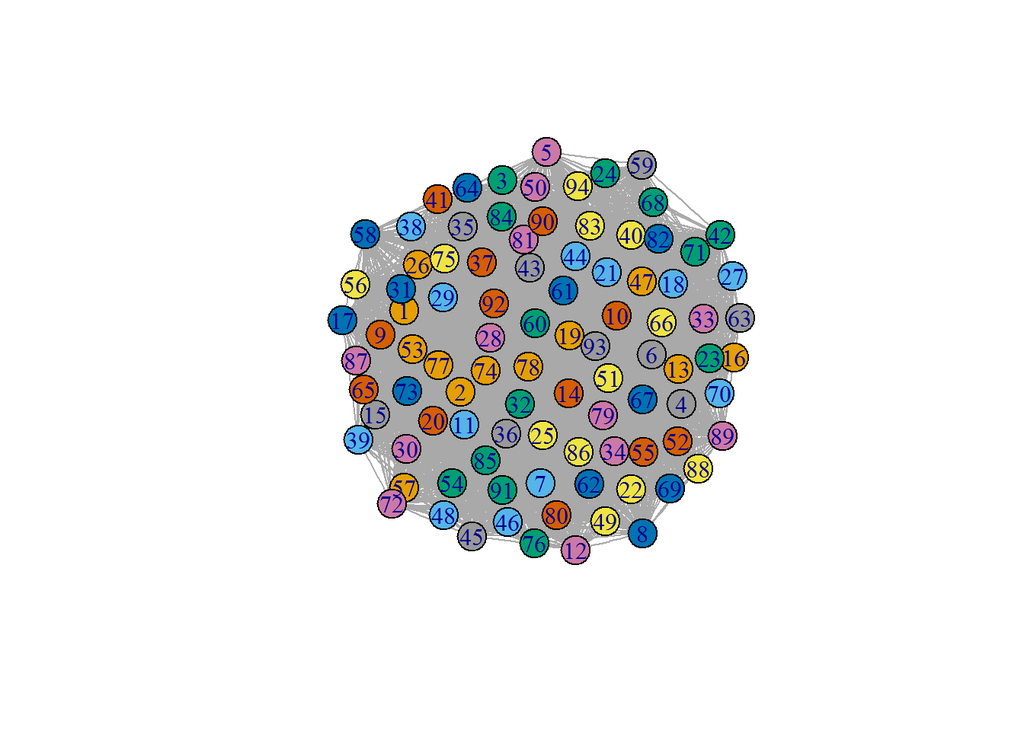

```r
V(g)$color <- colorGraph.DSATUR(neighbourList)
plot(g)
```

### VĂ˝sledky

#### PĹ™ehled poÄŤtu pouĹľitĂ˝ch barech pro konkrĂ©tnĂ algoritmus a kategorii + graf

```r
aggregate(nColors~edgesCategory+algorithm, data=results, f)
```

```
##    edgesCategory algorithm nColors.Min nColors.Max nColors.Mean nColors.Median
## 1              1     NAIVE       4.000       6.000        4.853          5.000
## 2              2     NAIVE       6.000       9.000        7.318          7.000
## 3              3     NAIVE      18.000      25.000       21.295         21.000
## 4              4     NAIVE      31.000      43.000       36.813         37.000
## 5              1        LF       4.000       5.000        4.104          4.000
## 6              2        LF       5.000       8.000        6.450          6.000
## 7              3        LF      17.000      24.000       19.827         20.000
## 8              4        LF      30.000      40.000       34.679         35.000
## 9              1        WP       4.000       5.000        4.104          4.000
## 10             2        WP       5.000       8.000        6.450          6.000
## 11             3        WP      17.000      24.000       19.827         20.000
## 12             4        WP      30.000      40.000       34.679         35.000
## 13             1       RLF       3.000       5.000        4.013          4.000
## 14             2       RLF       5.000       7.000        6.045          6.000
## 15             3       RLF      16.000      22.000       18.861         19.000
## 16             4       RLF      29.000      39.000       33.600         34.000
## 17             1    DSATUR       3.000       5.000        3.684          4.000
## 18             2    DSATUR       5.000       7.000        5.648          6.000
## 19             3    DSATUR      15.000      22.000       18.195         18.000
## 20             4    DSATUR      28.000      38.000       32.823         33.000
```

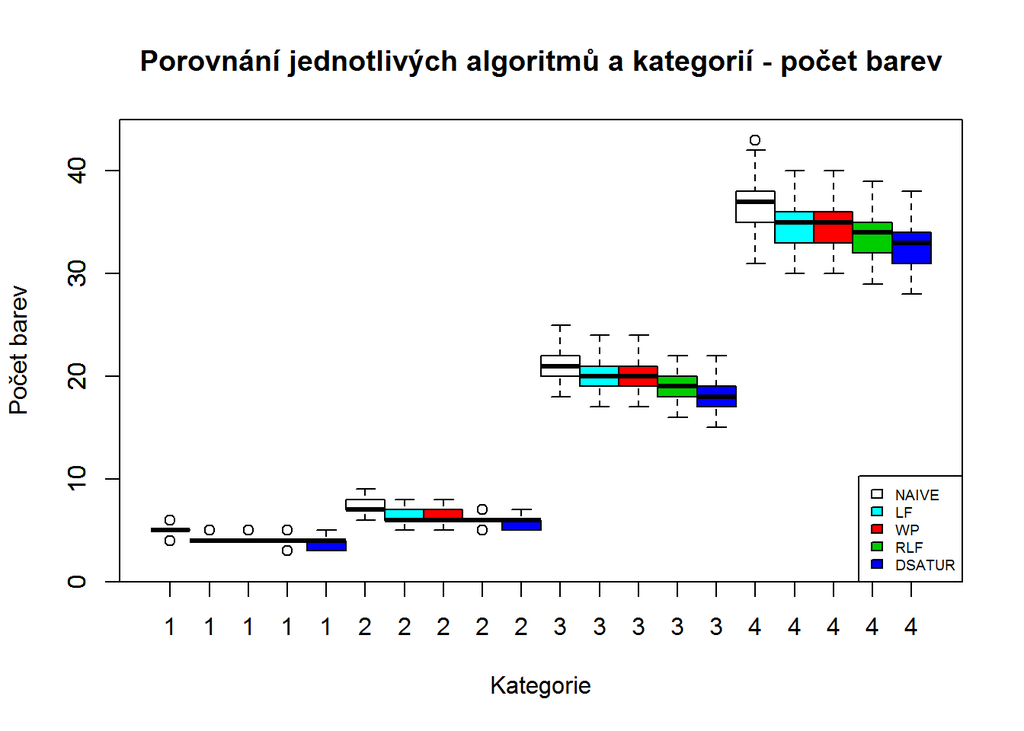

```r
boxplot(nColors ~ edgesCategory, data = results,
    boxwex = 0.2, at = 1:4 - 0.4,
    subset = algorithm == "NAIVE", col = 0,
    main = "PorovnĂˇnĂ jednotlivĂ˝ch algoritmĹŻ a kategoriĂ - poÄŤet barev",
    xlab = "Kategorie",
    ylab = "PoÄŤet barev",
    xlim = c(0.5, 4.5), ylim = c(0, max(results$nColors)+2), yaxs = "i")

boxplot(nColors ~ edgesCategory, data = results, add = TRUE,
    boxwex = 0.2, at = 1:4 - 0.2,
    subset = algorithm == "LF", col = 5)

boxplot(nColors ~ edgesCategory, data = results, add = TRUE,
    boxwex = 0.2, at = 1:4,
    subset = algorithm == "WP", col = 2)

boxplot(nColors ~ edgesCategory, data = results, add = TRUE,
    boxwex = 0.2, at = 1:4 + 0.2,
    subset = algorithm == "RLF", col = 3)

boxplot(nColors ~ edgesCategory, data = results, add = TRUE,
    boxwex = 0.2, at = 1:4 + 0.4,
    subset = algorithm == "DSATUR", col = 4)

legend("bottomright", c("NAIVE", "LF", "WP", "RLF", "DSATUR"), fill = c(0,5,2,3,4), cex = .6)
```

#### CelkovĂ˝ ÄŤas potĹ™ebnĂ˝ k obarvenĂ grafu danĂ© kategorie pomocĂ uvedenĂ©ho algoritmu

```r
timeAgg <- aggregate(runningTime~algorithm+edgesCategory, data=results, sum)
timeAgg
```

```
##    algorithm edgesCategory runningTime
## 1      NAIVE             1   0.9866178
## 2         LF             1   1.4752147
## 3         WP             1   1.7682998
## 4        RLF             1  12.8157496
## 5     DSATUR             1  97.9324834
## 6      NAIVE             2   1.4071505
## 7         LF             2   2.0493908
## 8         WP             2   2.4877636
## 9        RLF             2  12.9283862
## 10    DSATUR             2 103.5890141
## 11     NAIVE             3   6.2355053
## 12        LF             3   7.5628574
## 13        WP             3   9.1237338
## 14       RLF             3  11.4499369
## 15    DSATUR             3 132.7810278
## 16     NAIVE             4  13.8267655
## 17        LF             4  15.3413541
## 18        WP             4  18.5297952
## 19       RLF             4   9.2454848
## 20    DSATUR             4 150.6468642
```

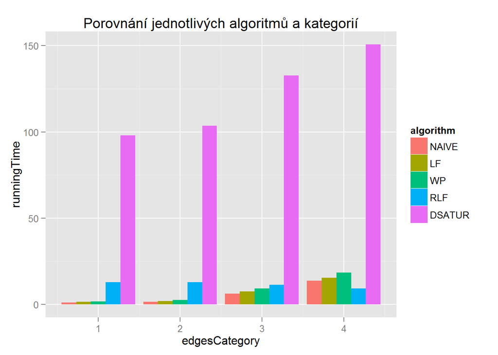

```r
ggplot(data=timeAgg, aes(x=edgesCategory, y=runningTime)) +
    geom_bar(aes(fill = algorithm), position = "dodge", stat="identity")+
    ggtitle("PorovnĂˇnĂ jednotlivĂ˝ch algoritmĹŻ a kategoriĂ")
```

#### ÄŚetnost souvislĂ˝ch grafĹŻ

```r
sG <- aggregate(components ~ edgesCategory, results[!duplicated(results[c(1,4)]),], function(x) sum(x==1) / runs)
colnames(sG) <- c("komponenta", "ÄŤetnost")
sG
```

```
##   komponenta ÄŤetnost
## 1          1   0.197
## 2          2   0.999
## 3          3   1.000
## 4          4   1.000
```

#### Jako poslednĂ pĹ™ehled poÄŤtu hran a vrcholĹŻ.

Nejprve jak vypadĂˇ rozdÄ›lenĂ poÄŤtu vrcholĹŻ, kterĂ© nezĂˇvisĂ na kategorii

```r
table(results[!duplicated(results[1]),]$nVertices)
```

```
##
##  90  91  92  93  94  95  96  97  98  99 100 101 102 103 104 105 106 107 108 109 110
##  54  48  42  35  50  44  60  45  49  52  47  53  46  46  47  48  33  50  56  48  47
```

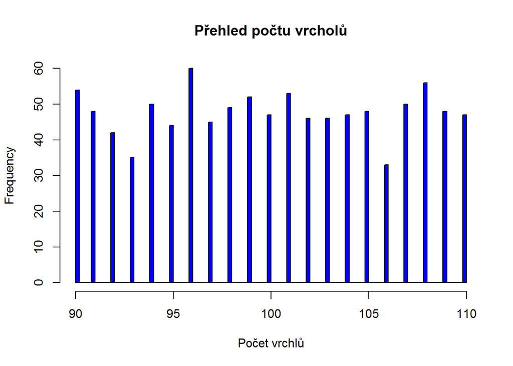

```r
hist(results[!duplicated(results[1]),]$nVertices, breaks = 100, col = "blue", main = "PĹ™ehled poÄŤtu vrcholĹŻ", xlab = "PoÄŤet vrchlĹŻ")
```

a nĂˇsleduje poÄŤet hran pro jednotlivĂ© kategorie - zĂˇvisĂ n poÄŤtu vrcholĹŻ

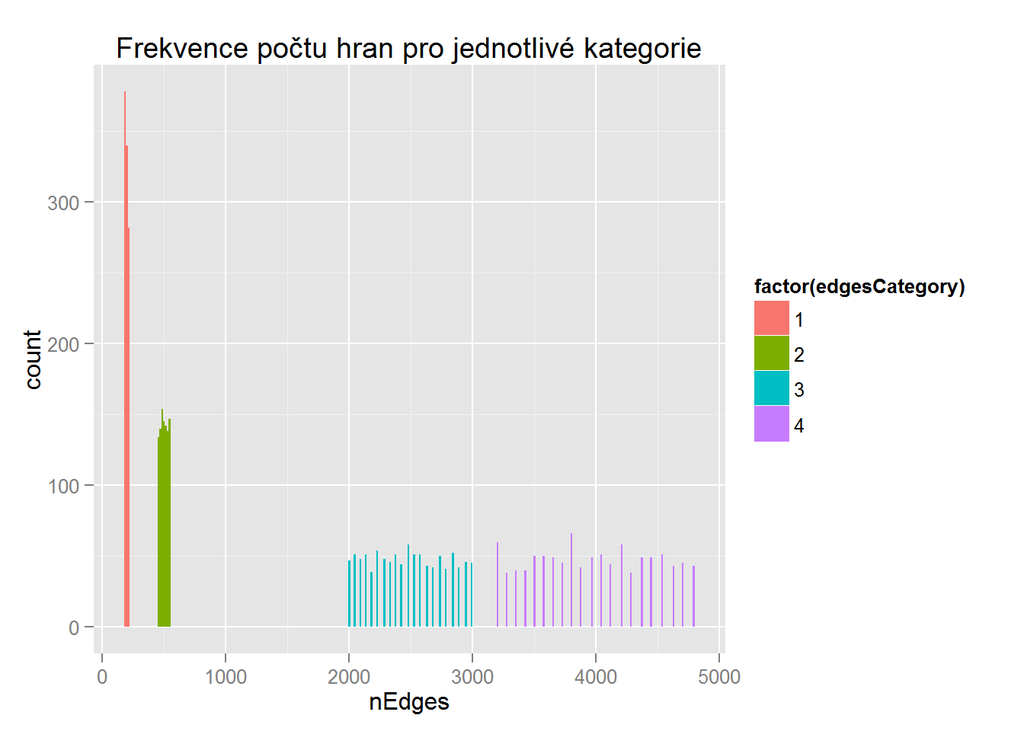

```r
ggplot(data=results[!duplicated(results[c(1,3)]),], aes(nEdges)) +
    geom_histogram(aes(fill = factor(edgesCategory)), binwidth = 15) +
    ggtitle("Frekvence poÄŤtu hran pro jednotlivĂ© kategorie")
```

## ZĂˇvÄ›r

NamÄ›Ĺ™enĂ© hodnoty dobĹ™e ilustrujĂ ÄŤasovou nĂˇroÄŤnost i poÄŤet pouĹľitĂ˝ch barev. VĂ˝bÄ›r konkrĂ©tnĂho algoritmu zĂˇvisĂ na oÄŤekĂˇvanĂ©m vĂ˝sledku (maximĂˇlnĂ rychlost, minimĂˇlnĂ poÄŤet barev â€¦) i vstupnĂm grafu (poÄŤtu vrcholĹŻ a hran).

## PĹ™Ăloha - namÄ›Ĺ™enĂ© hodnoty

```r
results
```

[output not shown]

[output cut: 12486 more lines]